# ANNFromScratch

## Artificial Neural Network (ANN) Derived and Coded from Scratch

#### Nikolay Oskolkov, SciLifeLab, NBIS Long Term Support, nikolay.oskolkov@scilifelab.se

### Abstract

In this notebook, we will implement a code for solving the XOR non-linear problem with Artificial Neural Network (ANN) that is a single hidden layer Perceptron model. First we will introduce the XOR problem, then we will implement the ANN via Keras, and finally derive and code it from scratch in Python.

### Table of Contents:

- XOR Non-Linear Problem
- Solving XOR in Keras
- Deriving and Coding ANN from Scratch

### XOR Non-Linear Problem

XOR was an example of a problem that could not be solved with a simple Perceptron model. The reson was that an ANN without hidden layers could solve only linear problems while XOR was a simplest example of a non-linear problem.

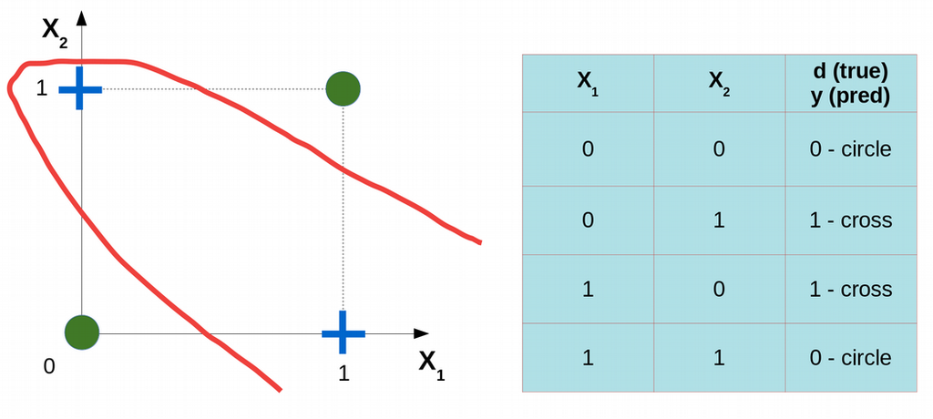

```python
from IPython.display import Image
Image('/home/nikolay/Documents/Medium/ANN_From_Scratch/XOR.png', width = 2000)
```

ANN without a hidden layer is capable of making a linear desicion boundary. From the figure above we can see that the XOR problem can not be solved with drawing a single linear decision boundary, i.e. crosses and circles can only be separated with a non-linear surface, like the read curve in the figure, or by two linear surfaces. Therefore an ANN with a hidden layer is required to solve the XOR problem.

### Solving XOR in Keras

We can easily implement the solution of the XOR problem with an ANN in Keras. Here we are going to use 1 hidden layer with 2 hidden neurons in addition to the input and output layers. Activation functions will be **Sigmoid** for both hidden and output layers. We will use the Mean Square Error (MSE) loss function and Stochastic Gradient Descent (SGD) with the Learnig Rate (lr) equal to 0.1, i.e. quite a large learning rate. Since we have a binary otcome, it would probably make more sense to use the Binary Cross-Entropy cost function, however here we will try to make the ANN as simple as possible, hence we choose the MSE cost function.

```python
import numpy as np
from tensorflow.keras.optimizers import SGD
from tensorflow.keras.models import Sequential
from tensorflow.keras.layers import Dense

X = np.array([[0,0],[0,1],[1,0],[1,1]])
y = np.array([[0],[1],[1],[0]])

model = Sequential()
model.add(Dense(2, input_dim = 2, activation = 'sigmoid'))
model.add(Dense(1, activation = 'sigmoid'))

model.compile(loss = 'mse', optimizer = SGD(lr = 0.1))
model.fit(X, y, epochs = 100000, verbose = 0)

model.predict(X)
```

```
array([[0.01595834],
       [0.9815781 ],
       [0.98158884],
       [0.01764232]], dtype=float32)
```

We can see that the ANN with one hidden layer and two hidden neurons can easily solve the XOR problem and get correct assignments to the 4 observations (2 crosses and 2 circles). However, please note the large number of training epoches (epoches = 100 000) that was needed to get the model converged to the true labels. This is because we are using the simpest possible architecture of ANN, i.e. with MSE cost function and only 1 hidden layer and only 2 hidden neurons. In addition we are using SGD and sigmoid activation functions. Those hyperparameters are not the smartest choice, and their better choise can dramatically decrease the training time.

### Deriving and Coding ANN from Scratch

Now we will implement an ANN with all the elements derived and programmed from scratch. Below we present the ANN architecture to be used. It includes the input layer taking 2 vectors x1 = (0 0 1 1) and x2 = (0 1 0 1), and 1 hidden layer with 2 hidden neurons h1 and h2. The output y gets a prediction from the ANN and compares it against the true labels d = (0 1 1 0).

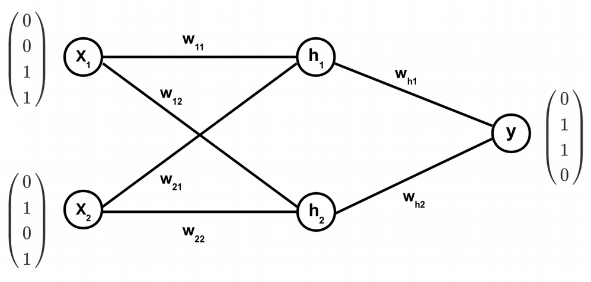

```python
from IPython.display import Image
Image('/home/nikolay/Documents/Medium/ANN_From_Scratch/ANN.png', width = 2000)
```

Both hidden and the output nodes have the sigmoid activation function that has a very simple derivatve that can be expressed through the function itself:

$$ \phi(s) = \frac{1}{1+e^{\displaystyle -s}}; \,\,\, \phi\prime(s)=\phi(s)\left(1-\phi(s)\right) $$

Then we can easily write down the input for each of the hidden neurons:

$$ h_1 = \phi(x_1 w_{11} + x_2 w_{21}) \\ h_2 = \phi(x_1 w_{12} + x_2 w_{22}) $$

The above two equations can be formalizes in a linear algebra matrix form as follows:

$$ h_j = \phi\left(\sum_{i=1}^2{x_i w_{ij}}\right); \,\,\, x_i = (x_1 \,\,\, x_2) = \begin{pmatrix} 0 & 0\\ 0 & 1\\ 1 & 0\\ 1 & 1 \end{pmatrix}; \,\,\, h_j = (h_1 \,\,\, h_2); \,\,\, w_{ij}= \begin{pmatrix} w_{11} & w_{12}\\ w_{21} & w_{22}\\ \end{pmatrix} $$

Please note that since $h_j$ is a vector-row with dimensions (1x2), and $x_1$ and $x_2$ are vector-columns with dimensions (4x1), the resulting output of the hidden layer, h, will be a matrix with dimensions (4x2). The output of the ANN can be expressed as a sigmoid of the linear combination of the two hidden neurons:

$$ y = \phi\left(\sum_{j=1}^2{h_j w_{hj}}\right); \,\,\, w_{hj} = \begin{pmatrix} w_{h1}\\ w_{h1} \end{pmatrix} $$

Here $w_{hj}$ is a vector-column with dimensions (2x1). Since $h_j$ was a matrix (4x2) and $w_{hj}$ was a vector (2x1), the product, y, will be a vector-column with dimensions (4x1). This output (prediction, y) will be compared against the true labels d, and the error will be given as quadratic deviation of the prediction, y, from the truw labels, d.

$$ E = \frac{1}{2}\left(d-y\right)^2 = \frac{1}{2}\left(d-\phi\left(\sum_{j=1}^2{h_j w_{hj}}\right)\right)^2 $$

The hidden weights $w_{hj}$ and input weights $w_{ij}$ are updated via gradient descent from the computed error in such a way that first the hidden weights are updated from the error, and then the input weights are updated, implying that the updating occurs backwards, hence it is called **backpropagation**.

$$ w_{hj} = w_{hj} - \mu\frac{\partial E(w_{hj})}{\partial w_{hj}};\\ \frac{\partial E(w_{hj})}{\partial w_{hj}} = \left[d-\phi\left(\sum_{j=1}^2{h_j w_{hj}}\right)\right]* \phi\left(\sum_{j=1}^2{h_j w_{hj}}\right)*\left(1-\phi\left(\sum_{j=1}^2{h_j w_{hj}}\right)\right)*h_j\\ w_{ij} = w_{ij} - \mu\frac{\partial E(w_{ij})}{\partial w_{ij}};\\ \frac{\partial E(w_{ij})}{\partial w_{ij}} = \frac{\partial E(w_{hj})}{\partial w_{hj}}*w_{hj}* \phi\left(\sum_{i=1}^2{x_i w_{ij}}\right)\left(1-\phi\left(\sum_{i=1}^2{x_i w_{ij}}\right)\right)*x_i $$

Now, once we have gotten the expressions for the error gradinets, everything is ready for programming the forward and backward propagations. We start with defining the vectors $x_1$ and $x_2$, combining them into a matrix (4x2) and defining the vector d, which is the true labels of the 4 XOR samples that we are going to learn. Please note that d is a vector-column with dimensions (4x1).

```python
import numpy as np
x1 = np.array([0, 0, 1, 1])
x2 = np.array([0, 1, 0, 1])
d = np.array([[0],[1],[1],[0]])
x = np.array([[i, j] for i,j in zip(x1, x2)])
x
```

```
array([[0, 0],
       [0, 1],
       [1, 0],
       [1, 1]])
```

Here we will define two functions: one is the sigmoid activation function to be used after the linear transform on each node, and the other is the derivative / gradient of the sigmoid function.

```python
def sigmoid(x):
    return 1 / (1 + np.exp(-x))
def grad_sigmoid(x):
    return sigmoid(x) * (1 - sigmoid(x))
```

We will start the forward propagation with assigning random values to the elements of the $w_{ij}$ matrix. We chose them to be 0.1, 0.5, 0.2 and 0.9, however in reality they should have been drawn from a uniform ditribution. Further, we compute the matrix product between the input matrix and the $w_{ij}$ matrix, this will be the output for the two hidden nodes, as a result we can see a (4x2) h-matrix.

```python
w = np.array([[0.1, 0.5], [0.2, 0.9]])
h = sigmoid(np.dot(x, w))
h
```

```
array([[0.5       , 0.5       ],
       [0.549834  , 0.7109495 ],
       [0.52497919, 0.62245933],
       [0.57444252, 0.80218389]])
```

Next, we assign random weights to the two hidden nodes (in this case it will be 0.9 and 0.9), and we will compute the output prediction, i.e. y-variable, as a sigmoid transform of the product of the hidden nodes output and the vector of hidden weights $w_{hj}$. As a result, we get a vector-column of y-predictions. Those should be (0 1 1 0) at the end, but now the numbers in this column do not make much sense as we have not yet computed the error and updated the weights.

```python
wh = np.array([[0.9], [0.9]])
y = sigmoid(np.dot(h, wh))
y
```

```
array([[0.7109495 ],
       [0.75670617],
       [0.73743798],
       [0.77538359]])
```

Now using the expression for the gradient of the mean square error with respect to the hidden weights above, we can use the error = d - y to update the hidden weights. Here $y*(1-y)$ is simply the derivative $y\prime$ of the prediction, y, at the output node. Please note the the matrix product of $dE_dwh$ and $h_j$ will be done later on the step when we update the hidden weights via gradient descent.

```python
dE_dwh = (d - y) * y * (1 - y)
dE_dwh
```

```
array([[-0.14610034],
       [ 0.04479087],
       [ 0.0508381 ],
       [-0.13504381]])
```

Next, the error gradient with respect to the hidden weights, dE*dwh, is included into the expression for the error gradient with respect to the input weights $w*{ij}$. Again, here $h*(1-h)$ is the derivative, $h\prime$, of the output of the hidden node, $h$. Since dE_dwh has dimensions (4x1) and $w_h$ has dimensions (2x1), we have to transpose $w_h$ in oder to compute its matrix product with dE_dwh. As a result, the dimensions of the dE_dw matrix is going to be (4x2), i.e. the same as the h-matrix. One more thing to note is that the matrix multiplication is done via np.dot() numpy function while element-wise multiplication is simply done via the asterics (*) operator.

```python
dE_dw = np.dot(dE_dwh, wh.T) * h * (1 - h)
dE_dw
```

```
array([[-0.03287258, -0.03287258],
       [ 0.00997783,  0.00828408],
       [ 0.01141002,  0.01075243],
       [-0.02971132, -0.01928647]])
```

Finally, after we computed the error gradients with respect to the hidden and input weights, we are going to update the hidden weights $w_h$ and input weights $w_{ij}$ via gradient descent. On the fly, we will multiply the input $x_j$ and output of the hidden node $h_j$ by the gradients dE_dw and dE_dwh, respectively following matrix multiplication rules. Here we select the lerning rate mu = 0.1 for faster convergence of the gradient descent procedure, this will work for this simple task, although normally for real-world applications one should use smaller lerning rates.

```python
mu = 0.1
wh = wh + mu * np.dot(h.T, dE_dwh)
wh
```

```
array([[0.89006914],
       [0.88821086]])
```

```python
w = w + mu * np.dot(x.T, dE_dw)
w
```

```
array([[0.09816987, 0.4991466 ],
       [0.19802665, 0.89889976]])
```

Great, seems like we can follow and code both forward and backward propagation steps. Let us now merge all the codes above together into a single piece. Repeating the update rule iteratively, we obtain a simple loop:

```python
import numpy as np

x1 = np.array([0, 0, 1, 1])
x2 = np.array([0, 1, 0, 1])
d = np.array([[0],[1],[1],[0]])
x = np.array([[i, j] for i,j in zip(x1, x2)])

def sigmoid(x):
    return 1 / (1 + np.exp(-x))
def grad_sigmoid(x):
    return sigmoid(x) * (1 - sigmoid(x))

mu = 0.1
epochs = 100000
w = np.array([[0.1, 0.5], [0.2, 0.9]])
wh = np.array([[0.9], [0.9]])

E = list()
for i in range(epochs):

    #Forward propagation
    h = sigmoid(np.dot(x, w))
    y = sigmoid(np.dot(h, wh))

    #Backward propagation
    E.append(np.array((d - y)**2).sum())
    dE_dwh = (d - y) * y * (1 - y)
    wh = wh + mu * np.dot(h.T, dE_dwh)

    dE_dw = np.dot(dE_dwh, wh.T) * h * (1 - h)
    w = w + mu * np.dot(x.T, dE_dw)
```

```python
wh
```

```
array([[-33.11408773],
       [ 26.33554427]])
```

```python
w
```

```
array([[0.92638916, 7.72066293],
       [0.92639074, 7.72154075]])
```

```python
y
```

```
array([[0.03263268],
       [0.93104443],
       [0.93104445],
       [0.09195182]])
```

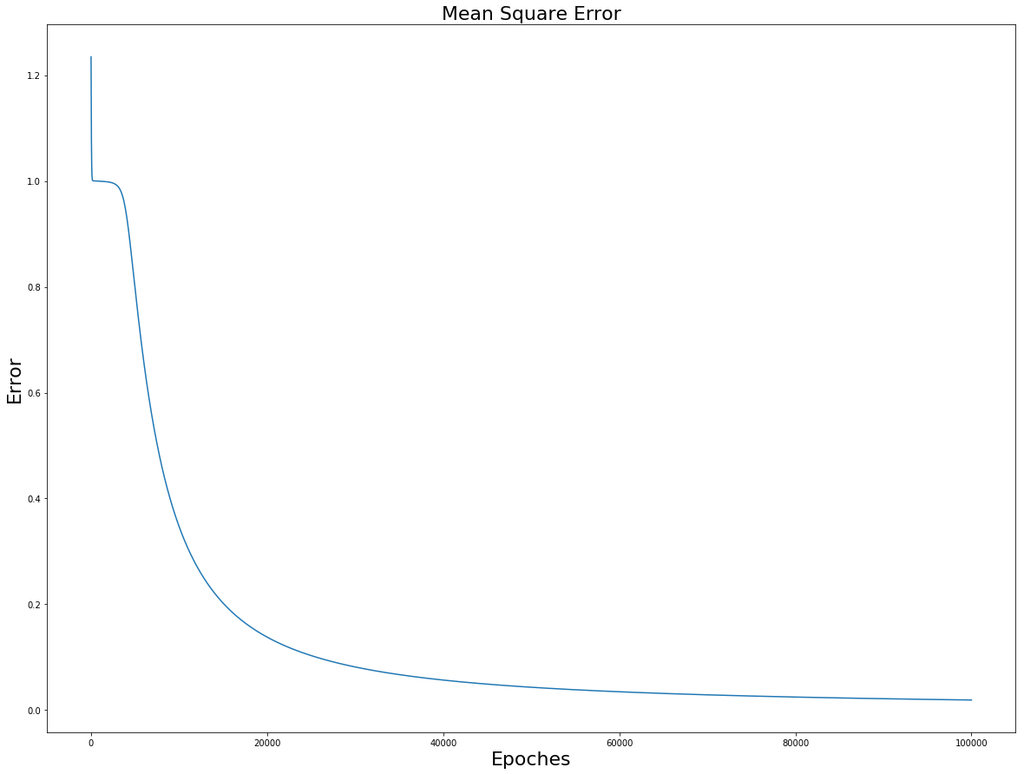

```python
import matplotlib.pyplot as plt
plt.figure(figsize = (20, 15))
plt.plot(range(epochs), E)
plt.title('Mean Square Error', fontsize = 22)
plt.xlabel('Epoches', fontsize = 22)
plt.ylabel('Error', fontsize = 22)
plt.show()
```

Looks like indeed the error is decreasing and reaching some plateau, while the value at the output node converges to a vector close to (0 1 1 0), which is the true labels of the XOR non-linear problem. Congratulations! We have codded the forward and backpropagation from scratch using just numpy and were able to successfully solve the XOR problem.